# QTM 347 HW 1 Combined

### DATASCI 347: Machine Learning 1 (Fall 2025) Machine Learning 1 — HW 1 (Python)

#### Group Members: Peter Chen, Aadit Narayanan, Daniel Nickas

### 2 Case study 1: Audience Size

#### 2.1 Data preparation

```python
import pandas as pd
import numpy as np
import matplotlib.pyplot as plt
import seaborn as sns

df = pd.read_csv('c:/Users/Leonh/Downloads/Survey_results_final.csv')

columns_of_interest = {
    'Answer.Age': 'age',
    'Answer.Gender': 'gender',
    'Answer.Education': 'education',
    'Answer.HouseHoldIncome': 'income',
    'Answer.Sirius Radio': 'sirius',
    'Answer.Wharton Radio': 'wharton',
    'WorkTimeInSeconds': 'worktime'
}
df = df[list(columns_of_interest.keys())].rename(columns=columns_of_interest)

print("Original shape of the data:", df.shape)
df.head()
```

```
Original shape of the data: (1764, 7)
```

|  | age | gender | education | income | sirius | wharton | worktime |
| --- | --- | --- | --- | --- | --- | --- | --- |
| 0 | 21 | Female | Some college, no diploma; or Associate’s degree | $30,000 - $50,000 | No | No | 12 |
| 1 | 56 | Female | Some college, no diploma; or Associate’s degree | $15,000 - $30,000 | No | No | 25 |
| 2 | 40 | Female | Graduate or professional degree | $50,000 - $75,000 | Yes | No | 13 |
| 3 | 52 | Female | Graduate or professional degree | Above $150,000 | Yes | Yes | 33 |
| 4 | 33 | Male | Bachelor’s degree or other 4-year degree | $30,000 - $50,000 | No | No | 13 |

```python
# Coerce to numeric, turning non-numeric strings into NaN
df['age'] = pd.to_numeric(df['age'], errors='coerce')
# Remove rows where age is NaN or is an outlier
df.dropna(subset=['age'], inplace=True)
df = df[df['age'] <= 100]
df['age'] = df['age'].astype(int)
# Clean 'education' and 'gender' columns for placeholder values
df['education'] = df['education'].replace('select one', np.nan)
df['gender'] = df['gender'].replace('select one', np.nan)
# It's impossible to be a Wharton listener without being a Sirius listener.
inconsistent_responses = df[(df['sirius'] == 'No') & (df['wharton'] == 'Yes')]
print(f"Found {len(inconsistent_responses)} inconsistent responses. Removing them.")
df = df.drop(inconsistent_responses.index)
df.replace('', np.nan, inplace=True)

print("\nShape of the data after cleaning:", df.shape)
print("\nMissing values after cleaning:")
print(df.isnull().sum())
```

```
Found 2 inconsistent responses. Removing them.

Shape of the data after cleaning: (1757, 7)

Missing values after cleaning:
age           0
gender        6
education    18
income        5
sirius        4
wharton       3
worktime      0
dtype: int64
```

2.1 ii) Our initial dataset contained 1764 responses. After cleaning, we were left with 1757 valid responses. Here are our cleaning process and their explanations:

1. Age Cleaning: We noticed that there are some non-numeric and outlier values in the 'age' column. Thus we converted the column to a numeric type, forcing invalid entries into NaN. We also removed rows with these invalid ages, as well as any clear outliers that don't make sense, such as the age > 100.
2. Logical Inconsistencies: We noticed that there are two respondents who claims to listen to Wharton Radio but not to Sirius Radio. Since Wharton Business Radio is a channel on SiriusXM, it doesn't make since that users claimed to listen to Wharton Radio but not to Sirius Radio, thus we have removed these rows.
3. Other missing values: We identified blank strings and placeholder values such as "select one" across the dataset and converted them to NaN to represent them as missing. We also decided to keep rows with missing demographic data, as they still contain valuable listenership information.

```
Summary of numeric columns:
               age     worktime
count  1757.000000  1757.000000
mean     30.429710    22.517359
std      10.005596     9.349659
min       4.000000     4.000000
25%      23.000000    17.000000
50%      28.000000    21.000000
75%      34.000000    26.000000
max      76.000000   108.000000

Value counts for categorical columns:

Gender:
gender
Male      1007
Female     744
NaN          6
Name: count, dtype: int64

Education:
education
Some college, no diploma; or Associate’s degree    743
Bachelor’s degree or other 4-year degree           614
High school graduate (or equivalent)               189
Graduate or professional degree                    181
NaN                                                 18
Less than 12 years; no high school diploma          10
Other                                                2
Name: count, dtype: int64

Income:
income
$30,000 - $50,000     427
$50,000 - $75,000     377
$15,000 - $30,000     365
$75,000 - $150,000    329
Less than $15,000     208
Above $150,000         46
NaN                     5
Name: count, dtype: int64

Sirius Listeners:
sirius
Yes    1358
No      395
NaN       4
Name: count, dtype: int64

Wharton Listeners:
wharton
No     1686
Yes      68
NaN       3
Name: count, dtype: int64
```

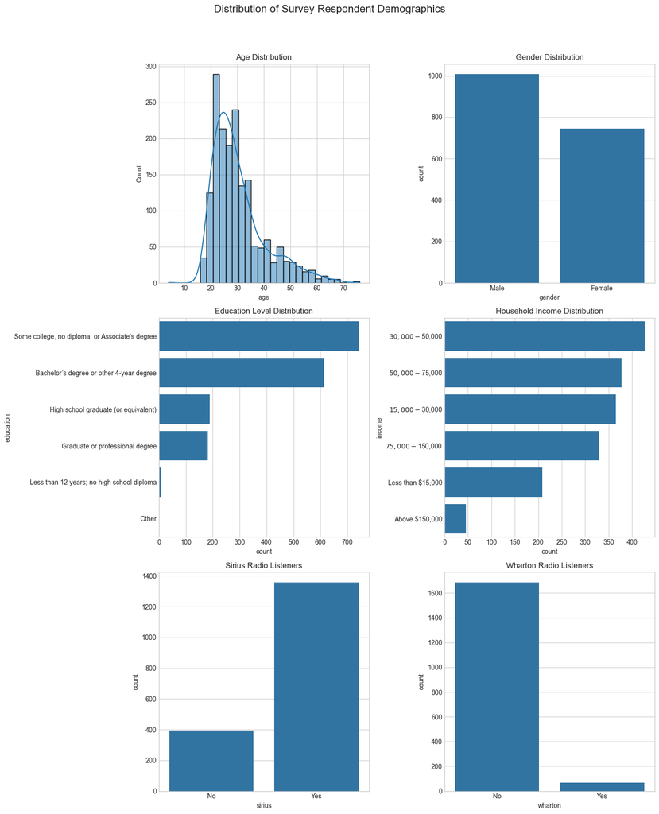

```python
print("Summary of numeric columns:")
print(df.describe())

print("\nValue counts for categorical columns:")
print("\nGender:")
print(df['gender'].value_counts(dropna=False))
print("\nEducation:")
print(df['education'].value_counts(dropna=False))
print("\nIncome:")
print(df['income'].value_counts(dropna=False))
print("\nSirius Listeners:")
print(df['sirius'].value_counts(dropna=False))
print("\nWharton Listeners:")
print(df['wharton'].value_counts(dropna=False))

plt.style.use('seaborn-v0_8-whitegrid')
fig, axes = plt.subplots(3, 2, figsize=(14, 18))
fig.suptitle('Distribution of Survey Respondent Demographics', fontsize=16)

# Age
sns.histplot(df['age'], bins=30, ax=axes[0, 0], kde=True)
axes[0, 0].set_title('Age Distribution')

# Gender
sns.countplot(x='gender', data=df, ax=axes[0, 1], order=df['gender'].value_counts().index)
axes[0, 1].set_title('Gender Distribution')

# Education
sns.countplot(y='education', data=df, ax=axes[1, 0], order=df['education'].value_counts().index)
axes[1, 0].set_title('Education Level Distribution')

# Income
sns.countplot(y='income', data=df, ax=axes[1, 1], order=df['income'].value_counts().index)
axes[1, 1].set_title('Household Income Distribution')

# Sirius Listenership
sns.countplot(x='sirius', data=df, ax=axes[2, 0])
axes[2, 0].set_title('Sirius Radio Listeners')

# Wharton Listenership
sns.countplot(x='wharton', data=df, ax=axes[2, 1])
axes[2, 1].set_title('Wharton Radio Listeners')

plt.tight_layout(rect=[0, 0.03, 1, 0.95])
plt.show()
```

2.1 iii) From the summary statistics and visualizations, we can observe the following about the survey respondents:

- Age: The respondents are relatively young. From the bell curve, most data is concentrated at a mean age of about 30 and a median of 28. It's also interesting that the distribution is skewed towards younger individuals. Gender: The sample is predominantly male (1007 respondents) compared to female (744 respondents).
- Education: A large portion of the respondents have "Some college, no diploma; or Associate’s degree" (743) followed by those with a "Bachelor’s degree" (614). From this we can tell that the sample of this experiment are mostly students/educated people with prior knowledge and understanding of the experiment.
- Income: The most common income bracket is "$30,000 - $50,000". A significant number of respondents have an annual household income below $50,000, which is a reasonable range for students and people who have justed graduated and entered the workforce.
- Listenership: A vast majority of respondents reported listening to Sirius Radio. However, only a small fraction of those listen to the Wharton Business Radio.

This demographic profile suggests that the MTurk workers who took this survey are likely younger individuals, possibly students or those early in their careers, who are looking to supplement their income.

#### 2.2 Sample properties

2.2 i) We compared our data and its demographics to that of the U.S. population in 2014(not current because thats when the experiment was implemented) to determine if our sample is representiive.

- Age: The median age in the U.S. in 2014 was approximately 37.6 years. Our sample has a median age of 28, which is significantly younger.
  - Source: United States Census Bureau, "Annual Estimates of the Resident Population for Selected Age Groups by Sex for the United States, States, Counties, and Puerto Rico Commonwealth and Municipios: April 1, 2010 to July 1, 2014." https://www.census.gov/data/tables/2014/demo/popest/nation-detail.html
- Gender: The U.S. population in 2014 was approximately 50.8% female. Our sample is about 42% female (744 out of 1751 non-missing gender entries), meaning it is skewed towards males.
  - Source: United States Census Bureau, "Annual Estimates of the Resident Population by Sex, Race, and Hispanic Origin for the United States, States, and Counties: April 1, 2010 to July 1, 2014." https://www.census.gov/data/tables/2014/demo/popest/nation-detail.html
- Education: In 2014, about 32% of the U.S. population aged 25 and over had a bachelor's degree or higher. In our sample (excluding those under 25 for a rough comparison), the proportion is much higher.
  - Source: United States Census Bureau, "Educational Attainment in the United States: 2014." https://www.census.gov/data/tables/2014/demo/education-attainment/cps-detailed-tables.html
- Income: The median household income in the U.S. in 2014 was around $53,700. Our sample's income distribution is skewed towards lower brackets due to the majority of our expriemnt subjects are young and students.
  - Source: United States Census Bureau, "Income and Poverty in the United States: 2014." https://www.census.gov/library/publications/2015/demo/p60-252.html

Based on these observations and outside sources, and comparing to our data distribution, NO, this sample does not appear to be a random sample from the general U.S. population. It is younger, more male, more educated, and has a lower household income on average.

2.2 ii)  
Research on MTurk demographics from around 2014 indicates that the MTurk population itself is not representative of the U.S. population. Studies conducted around 2014 consistently found that MTurk workers are younger, more educated, and have lower incomes than the general U.S. population.

- Source: Paolacci, G., Chandler, J., & Ipeirotis, P. G. (2010). "Running experiments on Amazon Mechanical Turk." Judgment and Decision Making, 5(5), 411-419.
- Source: Berinsky, A. J., Huber, G. A., & Lenz, G. S. (2012). "Evaluating online labor markets for experimental research: Amazon.com's Mechanical Turk." Political Analysis, 20(3), 351-368.

Our sample's demographics align well with these known characteristics of the MTurk population. For instance, one study from that era found that MTurk workers were more likely to be female, while our sample is majority male, so there might be some sampling bias even within the MTurk population, also others have found a more even split or a male majority, suggesting that gender distribution can vary depending on the specific task and time of the survey. However, the age and income distributions are quite consistent with typical MTurk worker profiles.

- Source: Ross, J., Irani, L., Silberman, M. S., Zaldivar, A., & Tomlinson, B. (2010). "Who are the crowdworkers?: shifting demographics in mechanical turk." CHI'10 extended abstracts on human factors in computing systems, 2863-2872.

So we came into the conclusion that even though its not the perfect fit, the sample is more representative of the MTurk populiation based on academic research on the demographics of Amazon Mechanical Turk Workers.

#### 2.3 Final estimate

```python
total_sirius_listeners = 51600000

sirius_listeners_sample = df[df['sirius'] == 'Yes'].shape[0]
wharton_listeners_sample = df[df['wharton'] == 'Yes'].shape[0]

proportion = wharton_listeners_sample / sirius_listeners_sample

estimated_audience = proportion * total_sirius_listeners

print(f"Number of Sirius listeners in sample: {sirius_listeners_sample}")
print(f"Number of Wharton listeners in sample: {wharton_listeners_sample}")
print(f"Proportion of Wharton listeners among Sirius listeners: {proportion:.4f}")
print(f"Estimated Wharton Business Radio Audience Size: {int(estimated_audience):,}")
```

```
Number of Sirius listeners in sample: 1358
Number of Wharton listeners in sample: 68
Proportion of Wharton listeners among Sirius listeners: 0.0501
Estimated Wharton Business Radio Audience Size: 2,583,799
```

2.3 Executive Summary

1. Goal of the Study: The primary goal of this study was to estimate the total audience size for the "Business Radio Powered by the Wharton School" show on SiriusXM as of May 2014.
2. Method: A survey was conducted on Amazon Mechanical Turk (MTurk), gathering 1757 valid responses from a U.S. based audience. We calculated the proportion of respondents who listen to Wharton Business Radio among those who listen to SiriusXM. This proportion was then multiplied by the total number of SiriusXM subscribers in January 2014 (51.6 million) to estimate the total audience size.
3. Findings: Within our sample, we found that approximately 5.01% of SiriusXM listeners also listen to the Wharton Business Radio channel. Based on this proportion, we estimate the total audience for the Wharton show to be approximately 2,583,799 listeners.
4. Limitations: The main limitation of this study is the reliance on a sample from MTurk. As established, this sample is not representative of the general U.S. population, and it may also not be representative of the SiriusXM subscriber base. The demographics of our sample (younger, more educated, lower income) may have different listening habits than the overall SiriusXM audience. Therefore, the actual audience size could be different from our estimate.

#### 2.4 New Task

2.4 Proposal to Estimate Wharton Business Radio Audience Size

#### Method:

To get a more accurate and updated estimate of the audience size with a $1000 budget, we propose a multi-pronged approach:

- Targeted Online Surveys: Instead of a general MTurk survey, we should use platforms that allow for more specific demographic targeting, such as Prolific or YouGov. We can set quotas to ensure our sample more closely matches the demographics of the general U.S. population or, ideally, known demographics of satellite radio listeners. The survey would again ask about listenership of SiriusXM and the Wharton channel. Also to ensure statistical precision, we will aim for at least 400 confirmed SiriusXM listeners in the survey sample, which allows estimates with a margin of error of roughly ±3 percentage points.
- Social Media Analytics: We can analyze social media data (e.g., from X/Twitter, Reddit) for mentions of "Wharton Business Radio" and related keywords. While this won't give a direct audience count, it can provide insights into the engagement and demographics of the online audience, which can be used to supplement survey findings.

Timeline:

- Feb 8–15: Launch survey and collect data
- Feb 16–20: Clean and analyze survey responses
- Feb 21–25: Collect and summarize social media analytics
- Mar 1: Deliver report

#### Data to Collect and Sources

- Survey Data:
  - SiriusXM listenership (Yes/No)
  - Wharton Business Radio listenership (Yes/No)
  - Frequency of listening ( daily, weekly, monthly)
  - demographics: age, gender, income, education, geographic region
- Public data:
  - updated total number of SiriusXM subscribers of 2021
  - Demographic data of satellite radio listeners if available from market research firms or industry reports

Budget

- Respondent incentives (~$0.80–0.90 for 1,000 completes): ~$840
- Platform fees: ~$140
- Total: ≤ $1,000

### Case study 2: Women in Science

```python
import pandas as pd
import matplotlib.pyplot as plt
import seaborn as sns
df = pd.read_excel("c:/Users/Leonh/Downloads/WomenData_06_16.xlsx")
df
```

|  | Field and sex | Degree | Sex | Year | Degrees Awarded |
| --- | --- | --- | --- | --- | --- |
| 0 | Agricultural sciences | BS | Female | 2006 | 8909 |
| 1 | Biological sciences | BS | Female | 2006 | 45055 |
| 2 | Computer sciences | BS | Female | 2006 | 9939 |
| 3 | Earth, atmospheric, and ocean sciences | BS | Female | 2006 | 1646 |
| 4 | Mathematics and statistics | BS | Female | 2006 | 6875 |
| ... | ... | ... | ... | ... | ... |
| 655 | Physical sciences | PhD | Male | 2016 | 3507 |
| 656 | Psychology | PhD | Male | 2016 | 1233 |
| 657 | Social sciences | PhD | Male | 2016 | 2658 |
| 658 | Engineering | PhD | Male | 2016 | 7929 |
| 659 | Non-S&E | PhD | Male | 2016 | 11633 |

660 rows × 5 columns

```python
df = df.rename(columns={'Field and sex': 'Field', 'Degrees Awarded' : 'Number'})
df['Field'] = df['Field'].astype('string')
df['Degree'] = df['Degree'].astype('string')
df['Sex'] = df['Sex'].astype('string')
df['Year'] = df['Year'].astype('int')
df['Number'] = df['Number'].astype('int')
print(df.isnull().sum())
```

```
Field     0
Degree    0
Sex       0
Year      0
Number    0
dtype: int64
```

There are 5 fields (Field, Degree, Sex, Year, Number). The years range from 2006 to 2016 and there are three different kids of degrees (BS,MS, PhD)

The years range from 2006 to 2016 and there are three different kids of degrees (BS,MS, PhD)

```
Sex             Female    Male
Field_Category
Non-S&E         958591  599967
Science         137112  220459
```

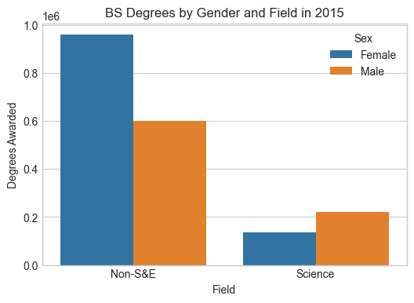

```python
df_2015_bs = df[(df['Year'] == 2015) & (df['Degree'] == 'BS')].copy()
se_fields = {
    'Agricultural sciences',
    'Biological sciences',
    'Computer sciences',
    'Earth, atmospheric, and ocean sciences',
    'Mathematics and statistics',
    'Physical sciences',
    'Engineering'
}
df_2015_bs['Field_Category'] = df_2015_bs['Field'].apply(lambda x: 'Science' if x.strip() in se_fields else 'Non-S&E')
summary = (df_2015_bs.groupby(['Field_Category', 'Sex'], as_index=False)['Number'].sum())
summary_pivot = summary.pivot(index='Field_Category', columns='Sex', values='Number')
print(summary_pivot)
categories = summary_pivot.index.tolist()
female_vals = summary_pivot['Female'].values
male_vals = summary_pivot['Male'].values
plt.figure(figsize=(6,4))
sns.barplot(data=summary, x='Field_Category', y='Number', hue='Sex')
plt.title('BS Degrees by Gender and Field in 2015')
plt.ylabel('Degrees Awarded')
plt.xlabel('Field')
plt.show()
```

No, there is not since strong evidence to say that there are more males. There are more males in science fields, but there are more women in non-s&e fields.

```
Degree                                  Field   Female     Male     Total  Pct_Female
    BS                  Agricultural sciences  16234.0  13226.0   29460.0    0.551052
    BS                    Biological sciences  68570.0  46554.0  115124.0    0.595619
    BS                      Computer sciences  10863.0  49446.0   60309.0    0.180122
    BS Earth, atmospheric, and ocean sciences   2701.0   4454.0    7155.0    0.377498
    BS                            Engineering  20057.0  79849.0   99906.0    0.200759
    BS             Mathematics and statistics   9922.0  13214.0   23136.0    0.428855
    BS                                Non-S&E 772768.0 493304.0 1266072.0    0.610367
    BS                      Physical sciences   8765.0  13716.0   22481.0    0.389885
    BS                             Psychology  91688.0  27080.0  118768.0    0.771992
    BS                        Social sciences  94135.0  79583.0  173718.0    0.541884
    MS                  Agricultural sciences   3228.0   2564.0    5792.0    0.557320
    MS                    Biological sciences   8326.0   6044.0   14370.0    0.579402
    MS                      Computer sciences   9607.0  21945.0   31552.0    0.304481
    MS Earth, atmospheric, and ocean sciences    955.0   1257.0    2212.0    0.431736
    MS                            Engineering  12282.0  36925.0   49207.0    0.249599
    MS             Mathematics and statistics   3380.0   4889.0    8269.0    0.408756
    MS                                Non-S&E 374024.0 209001.0  583025.0    0.641523
    MS                      Physical sciences   1678.0   3066.0    4744.0    0.353710
    MS                             Psychology  18926.0   5103.0   24029.0    0.787632
    MS                        Social sciences  23291.0  17489.0   40780.0    0.571138
   PhD                  Agricultural sciences    665.0    716.0    1381.0    0.481535
   PhD                    Biological sciences   4179.0   3711.0    7890.0    0.529658
   PhD                      Computer sciences    439.0   1512.0    1951.0    0.225013
   PhD Earth, atmospheric, and ocean sciences    359.0    468.0     827.0    0.434099
   PhD                            Engineering   2426.0   7980.0   10406.0    0.233135
   PhD             Mathematics and statistics    503.0   1299.0    1802.0    0.279134
   PhD                                Non-S&E  18396.0  11541.0   29937.0    0.614490
   PhD                      Physical sciences   1647.0   3324.0    4971.0    0.331322
   PhD                             Psychology   3343.0   1190.0    4533.0    0.737481
   PhD                        Social sciences   2703.0   2714.0    5417.0    0.498985
```

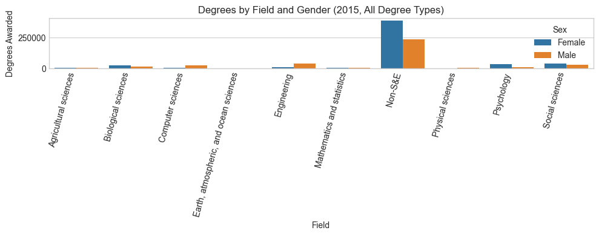

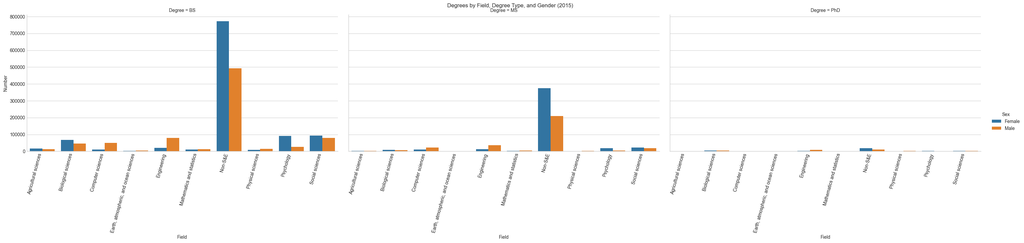

```python
df = df.copy()
df['Year'] = pd.to_numeric(df['Year'], errors='coerce')
df['Number'] = pd.to_numeric(df['Number'], errors='coerce')
df_2015 = df[df['Year'] == 2015].copy()
summary = (df_2015.groupby(['Degree', 'Field', 'Sex'], as_index=False)['Number'].sum())
table = (summary.pivot_table(index=['Degree','Field'], columns='Sex', values='Number', fill_value=0).reset_index())
if {'Female','Male'}.issubset(table.columns):
    table['Total'] = table['Female'] + table['Male']
    table['Pct_Female'] = np.where(table['Total'] > 0, table['Female'] / table['Total'], np.nan)
else:
    for col in ['Female','Male']:
        if col not in table.columns:
            table[col] = 0
    table['Total'] = table['Female'] + table['Male']
    table['Pct_Female'] = np.where(table['Total'] > 0, table['Female'] / table['Total'], np.nan)
table = table.sort_values(['Degree','Field']).reset_index(drop=True)
print(table[['Degree','Field','Female','Male','Total','Pct_Female']].to_string(index=False))
plt.figure(figsize=(10,4))
sns.barplot(data=summary, x='Field', y='Number', hue='Sex', errorbar=None)
plt.title("Degrees by Field and Gender (2015, All Degree Types)")
plt.xticks(rotation=75, ha="right")
plt.ylabel("Degrees Awarded")
plt.xlabel("Field")
plt.tight_layout()
plt.show()
g = sns.catplot(data=summary, x='Field', y='Number', hue='Sex', col='Degree', kind='bar', col_wrap=3, height=5, aspect=2)
g.set_xticklabels(rotation=75, ha="right")
g.fig.suptitle("Degrees by Field, Degree Type, and Gender (2015)", y=1)
plt.show()
```

Yes, there are gender effects. Men tend to be in more quantitative fields and women tend to be in more health-oriented fields.

```
                                     Field     Sex  Number_2006  Number_2016  \
0                    Agricultural sciences  Female        11487        21002
1                    Agricultural sciences    Male        10957        16924
2                      Biological sciences  Female        53174        85061
3                      Biological sciences    Male        34654        57240
4                        Computer sciences  Female        14864        24983
5                        Computer sciences    Male        51690        82350
6   Earth, atmospheric, and ocean sciences  Female         2625         4089
7   Earth, atmospheric, and ocean sciences    Male         3646         6239
8                              Engineering  Female        22301        39012
9                              Engineering    Male        85591       135488
10              Mathematics and statistics  Female         9346        14738
11              Mathematics and statistics    Male        12151        20800
12                                 Non-S&E  Female       946209      1181698
13                                 Non-S&E    Male       582078       718013
```

[output cut: 28 more lines]

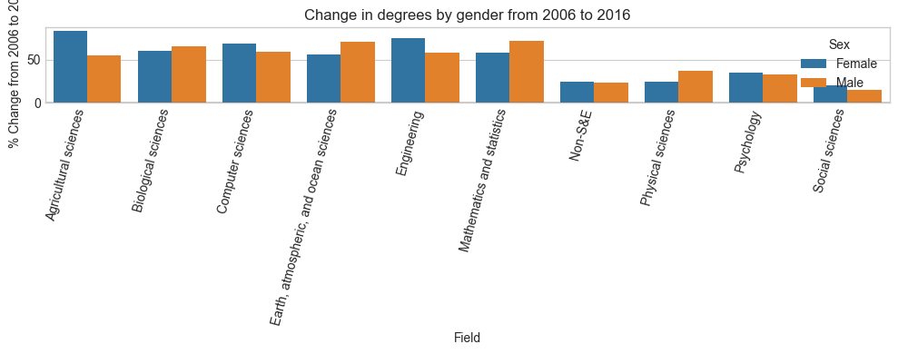

```python
df['Year'] = pd.to_numeric(df['Year'])
df['Number'] = pd.to_numeric(df['Number'])
df_2006 = df[df['Year'] == 2006]
df_2016 = df[df['Year'] == 2016]
agg_2006 = df_2006.groupby(['Field','Sex'])['Number'].sum().reset_index().rename(columns={'Number':'Number_2006'})
agg_2016 = df_2016.groupby(['Field','Sex'])['Number'].sum().reset_index().rename(columns={'Number':'Number_2016'})
change = pd.merge(agg_2006, agg_2016, on=['Field','Sex'])
change['Pct_Change'] = ((change['Number_2016'] - change['Number_2006']) / change['Number_2006']) * 100
change['Direction'] = change['Pct_Change'].apply(lambda x: 'Increase' if x > 0 else ('No change' if x == 0 else 'Decrease'))
print(change)
plt.figure(figsize=(10,4))
sns.barplot(data=change, x='Field', y='Pct_Change', hue='Sex', errorbar=None)
plt.axhline(0, color='black', linewidth=1)
plt.xticks(rotation=75, ha='right')
plt.title("Change in degrees by gender from 2006 to 2016")
plt.ylabel("% Change from 2006 to 2016")
plt.xlabel("Field")
plt.tight_layout()
plt.show()
```

I see a large increase of women in quantiative and scientific fields like agricultural, biological, and computer science.

```
      Sex  Number
0  Female   39721
1    Male  103150
```

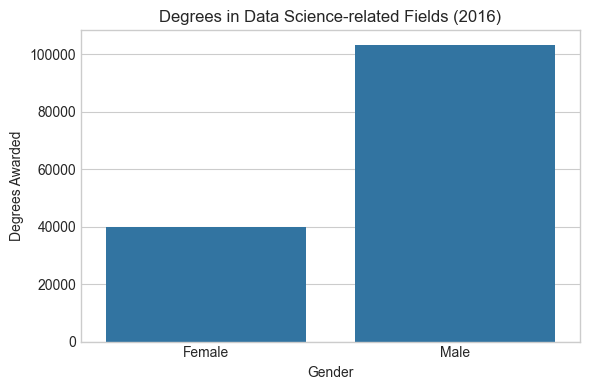

```python
df['Year'] = pd.to_numeric(df['Year'], errors='coerce')
df['Number'] = pd.to_numeric(df['Number'], errors='coerce')
df_2016 = df[df['Year'] == 2016].copy()
ds_fields = ['Computer sciences', 'Mathematics and statistics']
df_ds_2016 = df_2016[df_2016['Field'].isin(ds_fields)]
ds_summary = df_ds_2016.groupby('Sex')['Number'].sum().reset_index()
print(ds_summary)
plt.figure(figsize=(6,4))
sns.barplot(data=ds_summary, x='Sex', y='Number')
plt.title("Degrees in Data Science-related Fields (2016)")
plt.ylabel("Degrees Awarded")
plt.xlabel("Gender")
plt.tight_layout()
plt.show()
```

Based on the most recent year of the ddata, it looks like there is a significant disparity between male and females in data science fields.

I believe that there is a disparity between males and females in science-related fields. One concern with the dataset is that it only goes up to 2016. From 2006 to 2016, there was an increase in the amount of women in stem-related fields. I believe that this trend would have continued, especially with the boom in data science/AI. One way I would improve the study is to increase the number of years. I would also weight the data based on other factors, like income, graduation rates, etc. since those would affect one's chances at earning a degree.

### 4 Case study 3: Major League Baseball

##### Explore how payroll affects performance among MLB teams (1998–2014). Datasets provided:

##### MLPayData Total.csv (wide), baseball.csv (long). Use either.

```python
# import packages:
import pandas as pd
import numpy as np
import matplotlib.pyplot as plt
import seaborn as sns
import statsmodels.api as sm
from statsmodels.formula.api import ols
```

```python
bb = pd.read_csv('baseball.csv')
bb
```

|  | team | year | payroll | win_num | win_pct |
| --- | --- | --- | --- | --- | --- |
| 0 | Arizona Diamondbacks | 1998 | 31.614500 | 65 | 0.401235 |
| 1 | Arizona Diamondbacks | 1999 | 70.496000 | 100 | 0.617284 |
| 2 | Arizona Diamondbacks | 2000 | 81.027833 | 85 | 0.524691 |
| 3 | Arizona Diamondbacks | 2001 | 81.206513 | 92 | 0.567901 |
| 4 | Arizona Diamondbacks | 2002 | 102.820000 | 98 | 0.604938 |
| ... | ... | ... | ... | ... | ... |
| 505 | Washington Nationals | 2010 | 61.425000 | 69 | 0.425926 |
| 506 | Washington Nationals | 2011 | 63.681929 | 80 | 0.496894 |
| 507 | Washington Nationals | 2012 | 81.336143 | 98 | 0.604938 |
| 508 | Washington Nationals | 2013 | 114.056769 | 86 | 0.530864 |
| 509 | Washington Nationals | 2014 | 134.704437 | 96 | 0.592593 |

510 rows × 5 columns

#### 4.1 EDA: Relationship between payroll changes and performance

Argument: performance in year t might be more related to change in payroll from t − 1 to t than to level in t.

Create increment in payroll.

i) For year 2013, consider:

• diff: payroll2013 − payroll2012

• log diff: log(payroll2013) − log(payroll2012)

Explain why the log difference is more appropriate here.

The log difference is more appropriate because it decribes a percent change rather than an absolute change. For example, if a team spends 100mil one year and spends 200mil the next, then spending has doubled. However, if a team is spending 200mil and they spend 300mil the next year, then they only increased spending by 50%. The percent change is more likely to relate to changes in motivation than the absolute dollar difference ("according to expectancy theory and hedonistic adaptation").

However, the log difference approximating the percent change is more accurate for small percent changes (below 10% or so). The baseball dataset contains percent changes much higher; therefore, caution should be used in interpreting the results.

```python
# data structure:
print(bb.columns)
print(bb.dtypes)
print(bb.sort_values(by= ['team', 'year'], ascending=True).head(20))

# filter for years 2012 and 2013
baseball_12_13 = bb[(bb['year'] == 2012) | (bb['year'] == 2013)]

# create pivot tables columns as 'year'
payroll_pivot_12_13 = baseball_12_13.pivot(index='team', columns='year', values='payroll')
payroll_pivot_12_13.columns = ['payroll_2012', 'payroll_2013']

# calulating diff and log diff
payroll_pivot_12_13['pivot_diff'] = payroll_pivot_12_13['payroll_2013'] - payroll_pivot_12_13['payroll_2012']
payroll_pivot_12_13['log_diff'] = np.log(payroll_pivot_12_13['payroll_2013']) - np.log(payroll_pivot_12_13['payroll_2012'])
# convert to percentage change for ease of interpretation
payroll_pivot_12_13['percent_change'] = (payroll_pivot_12_13['payroll_2013'] - payroll_pivot_12_13['payroll_2012']) / payroll_pivot_12_13['payroll_2012'] * 100
payroll_pivot_12_13 = payroll_pivot_12_13.dropna()  # drop teams without complete data for both years
payroll_pivot_12_13
```

```
Index(['team', 'year', 'payroll', 'win_num', 'win_pct'], dtype='object')
team        object
year         int64
payroll    float64
win_num      int64
win_pct    float64
dtype: object
                    team  year     payroll  win_num   win_pct
0   Arizona Diamondbacks  1998   31.614500       65  0.401235
1   Arizona Diamondbacks  1999   70.496000      100  0.617284
2   Arizona Diamondbacks  2000   81.027833       85  0.524691
3   Arizona Diamondbacks  2001   81.206513       92  0.567901
4   Arizona Diamondbacks  2002  102.820000       98  0.604938
5   Arizona Diamondbacks  2003   80.640333       84  0.518519
6   Arizona Diamondbacks  2004   70.204984       51  0.314815
7   Arizona Diamondbacks  2005   63.015834       77  0.475309
8   Arizona Diamondbacks  2006   59.684226       76  0.469136
9   Arizona Diamondbacks  2007   52.067546       90  0.555556
10  Arizona Diamondbacks  2008   66.202712       82  0.506173
11  Arizona Diamondbacks  2009   73.571667       70  0.432099
12  Arizona Diamondbacks  2010   60.718167       65  0.401235
13  Arizona Diamondbacks  2011   53.639833       94  0.580247
14  Arizona Diamondbacks  2012   74.284833       81  0.500000
15  Arizona Diamondbacks  2013   89.100500       81  0.500000
16  Arizona Diamondbacks  2014  112.688666       64  0.395062
17        Atlanta Braves  1998   61.708000      106  0.654321
18        Atlanta Braves  1999   74.890000      103  0.635802
19        Atlanta Braves  2000   84.537836       95  0.586420
```

| team | payroll_2012 | payroll_2013 | pivot_diff | log_diff | percent_change |
| --- | --- | --- | --- | --- | --- |
| Arizona Diamondbacks | 74.284833 | 89.100500 | 14.815667 | 0.181858 | 19.944404 |
| Atlanta Braves | 83.309942 | 89.778192 | 6.468250 | 0.074774 | 7.764079 |
| Baltimore Orioles | 81.428999 | 90.993333 | 9.564334 | 0.111055 | 11.745612 |
| Boston Red Sox | 173.186617 | 150.655500 | -22.531117 | -0.139374 | -13.009733 |
| Chicago Cubs | 88.197033 | 104.304676 | 16.107643 | 0.167743 | 18.263248 |
| Chicago White Sox | 96.919500 | 119.073277 | 22.153777 | 0.205858 | 22.857915 |
| Cincinnati Reds | 82.203616 | 107.491305 | 25.287689 | 0.268211 | 30.762259 |
| Cleveland Indians | 78.430300 | 77.772800 | -0.657500 | -0.008419 | -0.838324 |
| Colorado Rockies | 78.069571 | 71.924071 | -6.145500 | -0.081989 | -7.871825 |
| Detroit Tigers | 132.300000 | 148.414500 | 16.114500 | 0.114937 | 12.180272 |
| Houston Astros | 60.651000 | 22.062600 | -38.588400 | -1.011252 | -63.623683 |
| Kansas City Royals | 60.916225 | 81.491725 | 20.575500 | 0.291002 | 33.776715 |
| Los Angeles Angels | 154.485166 | 127.896250 | -26.588916 | -0.188879 | -17.211307 |
| Los Angeles Dodgers | 95.143575 | 216.597577 | 121.454002 | 0.822654 | 127.653393 |
| Miami Marlins | 118.078000 | 36.341900 | -81.736100 | -1.178374 | -69.222124 |
| Milwaukee Brewers | 97.653944 | 82.976944 | -14.677000 | -0.162867 | -15.029603 |
| Minnesota Twins | 94.085000 | 75.802500 | -18.282500 | -0.216067 | -19.431897 |
| New York Mets | 93.353983 | 73.396649 | -19.957334 | -0.240520 | -21.378128 |
| New York Yankees | 197.962289 | 228.835490 | 30.873201 | 0.144927 | 15.595496 |
| Oakland Athletics | 55.372500 | 60.664500 | 5.292000 | 0.091276 | 9.557091 |
| Philadelphia Phillies | 174.538938 | 165.385714 | -9.153224 | -0.053867 | -5.244230 |
| Pittsburgh Pirates | 63.431999 | 79.555000 | 16.123001 | 0.226480 | 25.417772 |
| San Diego Padres | 55.244700 | 67.143600 | 11.898900 | 0.195061 | 21.538537 |
| San Francisco Giants | 117.620683 | 140.264334 | 22.643651 | 0.176064 | 19.251419 |
| Seattle Mariners | 81.978100 | 72.031143 | -9.946957 | -0.129354 | -12.133676 |
| St. Louis Cardinals | 110.300862 | 115.222086 | 4.921224 | 0.043650 | 4.461637 |
| Tampa Bay Rays | 64.173500 | 57.895272 | -6.278228 | -0.102955 | -9.783210 |
| Texas Rangers | 120.510974 | 114.090100 | -6.420874 | -0.054752 | -5.328041 |
| Toronto Blue Jays | 75.489200 | 117.527800 | 42.038600 | 0.442685 | 55.688231 |
| Washington Nationals | 81.336143 | 114.056769 | 32.720626 | 0.338106 | 40.228888 |

#### 4.1 EDA: Relationship between payroll changes and performance

ii) Create diff log for all years: log(payrollt) − log(payrollt−1).

```python
data_sorted = bb.sort_values(by=['team', 'year'])

data_sorted['prev_payroll'] = data_sorted.groupby('team')['payroll'].shift(1)
data_sorted['prev_year'] = data_sorted.groupby('team')['year'].shift(1)

# Calculate log difference (only where we have consecutive years)
data_sorted['consec_year'] = (data_sorted['year'] - data_sorted['prev_year'] == 1)
data_sorted['log_diff_payroll'] = np.where(
    data_sorted['consec_year'],
    np.log(data_sorted['payroll']) - np.log(data_sorted['prev_payroll']),
    np.nan
)
print(data_sorted)
diff_log = data_sorted[['team', 'year', 'log_diff_payroll','win_pct','win_num' ]].dropna()
diff_log.head()
```

```
                     team  year     payroll  win_num   win_pct  prev_payroll  \
0    Arizona Diamondbacks  1998   31.614500       65  0.401235           NaN
1    Arizona Diamondbacks  1999   70.496000      100  0.617284     31.614500
2    Arizona Diamondbacks  2000   81.027833       85  0.524691     70.496000
3    Arizona Diamondbacks  2001   81.206513       92  0.567901     81.027833
4    Arizona Diamondbacks  2002  102.820000       98  0.604938     81.206513
..                    ...   ...         ...      ...       ...           ...
505  Washington Nationals  2010   61.425000       69  0.425926     59.328000
506  Washington Nationals  2011   63.681929       80  0.496894     61.425000
507  Washington Nationals  2012   81.336143       98  0.604938     63.681929
508  Washington Nationals  2013  114.056769       86  0.530864     81.336143
509  Washington Nationals  2014  134.704437       96  0.592593    114.056769

     prev_year  consec_year  log_diff_payroll
0          NaN        False               NaN
1       1998.0         True          0.801940
2       1999.0         True          0.139237
3       2000.0         True          0.002203
4       2001.0         True          0.235984
..         ...          ...               ...
505     2009.0         True          0.034736
506     2010.0         True          0.036084
507     2011.0         True          0.244690
508     2012.0         True          0.338106
509     2013.0         True          0.166387

[510 rows x 9 columns]
```

|  | team | year | log_diff_payroll | win_pct | win_num |
| --- | --- | --- | --- | --- | --- |
| 1 | Arizona Diamondbacks | 1999 | 0.801940 | 0.617284 | 100 |
| 2 | Arizona Diamondbacks | 2000 | 0.139237 | 0.524691 | 85 |
| 3 | Arizona Diamondbacks | 2001 | 0.002203 | 0.567901 | 92 |
| 4 | Arizona Diamondbacks | 2002 | 0.235984 | 0.604938 | 98 |
| 5 | Arizona Diamondbacks | 2003 | -0.242981 | 0.518519 | 84 |

#### 4.1 EDA: Relationship between payroll changes and performance

iii) Create a long table with: team, year, diff log, win pct.

```python
# iii) Build a long table with: team, year, diff log, win pct
long_table = data_sorted[['team', 'year', 'log_diff_payroll', 'win_pct']]
long_table = long_table.dropna()
long_table['log_diff_payroll']= long_table['log_diff_payroll'].round(3)
long_table['win_pct']= long_table['win_pct'].round(3)

print("\nLong table with team, year, diff log, win pct:")
print(long_table.head(10))

long_table
```

```
Long table with team, year, diff log, win pct:
                    team  year  log_diff_payroll  win_pct
1   Arizona Diamondbacks  1999             0.802    0.617
2   Arizona Diamondbacks  2000             0.139    0.525
3   Arizona Diamondbacks  2001             0.002    0.568
4   Arizona Diamondbacks  2002             0.236    0.605
5   Arizona Diamondbacks  2003            -0.243    0.519
6   Arizona Diamondbacks  2004            -0.139    0.315
7   Arizona Diamondbacks  2005            -0.108    0.475
8   Arizona Diamondbacks  2006            -0.054    0.469
9   Arizona Diamondbacks  2007            -0.137    0.556
10  Arizona Diamondbacks  2008             0.240    0.506
```

|  | team | year | log_diff_payroll | win_pct |
| --- | --- | --- | --- | --- |
| 1 | Arizona Diamondbacks | 1999 | 0.802 | 0.617 |
| 2 | Arizona Diamondbacks | 2000 | 0.139 | 0.525 |
| 3 | Arizona Diamondbacks | 2001 | 0.002 | 0.568 |
| 4 | Arizona Diamondbacks | 2002 | 0.236 | 0.605 |
| 5 | Arizona Diamondbacks | 2003 | -0.243 | 0.519 |
| ... | ... | ... | ... | ... |
| 505 | Washington Nationals | 2010 | 0.035 | 0.426 |
| 506 | Washington Nationals | 2011 | 0.036 | 0.497 |
| 507 | Washington Nationals | 2012 | 0.245 | 0.605 |
| 508 | Washington Nationals | 2013 | 0.338 | 0.531 |
| 509 | Washington Nationals | 2014 | 0.166 | 0.593 |

480 rows × 4 columns

#### 4.2 Exploratory questions

i) Which five teams had the highest increase in payroll between 2010 and 2014 (inclusive)?

ii) Between 2010 and 2014 (inclusive), which team(s) “improved” the most in percentage gains in wins?

#### Answer to 4.2 (i): Teams with Highest Payroll Increase

Depending on what method you use to measure payroll increases from 2010-2014, the top five teams change. Here I've given top 5 teams in terms of logarithimic payroll increase (not absolute) because that provides a better measure of proportional change.

This aligns with the data shown in our results table, which identified these teams as having the highest log differences in payroll. As explained earlier, using log differences provides a better measurement of proportional changes in team payrolls than absolute dollar differences, especially when comparing teams with different financial resources.

```python
# Find largest year-to-year percent payroll increases within 2010-2014

# Use the loaded `data` DataFrame
data_10_14 = bb[bb['year'].between(2010, 2014)].copy()

# Sort and create lagged payroll and year
data_10_14 = data_10_14.sort_values(['team', 'year']).copy()
data_10_14['prev_payroll'] = data_10_14.groupby('team')['payroll'].shift(1)
data_10_14['prev_year'] = data_10_14.groupby('team')['year'].shift(1)

# I am keeping only data for consective years (this aligns with the sample solution provided)
data_10_14['is_consec'] = (data_10_14['year'] - data_10_14['prev_year'] == 1)
consec = data_10_14[data_10_14['is_consec'] & data_10_14['prev_payroll'].notna()].copy()

# Compute absolute change, percent change and log diff
consec['abs_change'] = consec['payroll'] - consec['prev_payroll']
consec['percent_change'] = (consec['payroll'] - consec['prev_payroll']) / consec['prev_payroll'] * 100
consec['log_diff'] = np.log(consec['payroll']) - np.log(consec['prev_payroll'])

# Top 5 by percent change
top5 = consec.sort_values('percent_change', ascending=False).head(5).copy()

# Round values for presentation
top5['percent_change_round'] = top5['percent_change'].round().astype(int)
top5['abs_change_round'] = top5['abs_change'].round(1)

show_tbl = top5[['team', 'year', 'log_diff', 'prev_payroll', 'payroll', 'abs_change', 'percent_change', ]].copy().round(3)
print(show_tbl.head())
```

```
                    team  year  log_diff  prev_payroll  payroll  abs_change  \
236  Los Angeles Dodgers  2013     0.823        95.144  216.598     121.454
252        Miami Marlins  2012     0.729        56.944  118.078      61.134
186       Houston Astros  2014     0.703        22.063   44.544      22.482
201   Kansas City Royals  2012     0.522        36.126   60.916      24.790
472        Texas Rangers  2011     0.513        55.251   92.299      37.049

     percent_change
236         127.653
252         107.358
186         101.899
201          68.620
472          67.056
```

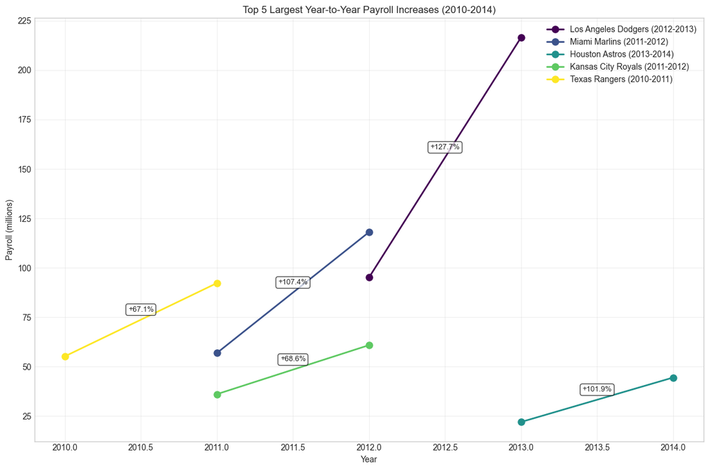

```python
# Analyzing the largest year-to-year changes in payroll within the 2010-2014 window

# Use the already loaded and filtered data_10_14 from cell 12
data_2010_2014_sorted = data_10_14.sort_values(['team', 'year'])

# Create previous year columns
data_2010_2014_sorted['prev_year'] = data_2010_2014_sorted.groupby('team')['year'].shift(1)
data_2010_2014_sorted['prev_payroll'] = data_2010_2014_sorted.groupby('team')['payroll'].shift(1)

# Calculate year-to-year changes (only where we have consecutive years)
data_2010_2014_sorted['is_consecutive'] = (data_2010_2014_sorted['year'] - data_2010_2014_sorted['prev_year'] == 1)
data_2010_2014_sorted['payroll_change'] = data_2010_2014_sorted['payroll'] - data_2010_2014_sorted['prev_payroll']
data_2010_2014_sorted['log_diff'] = np.where(
    data_2010_2014_sorted['is_consecutive'],
    np.log(data_2010_2014_sorted['payroll']) - np.log(data_2010_2014_sorted['prev_payroll']),
    np.nan
)
data_2010_2014_sorted['percent_change'] = np.where(
    data_2010_2014_sorted['is_consecutive'],
    (data_2010_2014_sorted['payroll'] - data_2010_2014_sorted['prev_payroll']) / data_2010_2014_sorted['prev_payroll'] * 100,
    np.nan
)

# Get the top 5 year-to-year changes by log difference (percent change)
top_5_yearly_changes = data_2010_2014_sorted.dropna(subset=['log_diff']).sort_values('log_diff', ascending=False).head(5)

# Create a visualization of these top changes
plt.figure(figsize=(12, 8))

# For each team in top 5, show the payroll before and after the big change
teams = top_5_yearly_changes['team'].unique()
colors = plt.cm.viridis(np.linspace(0, 1, len(teams)))

for i, team in enumerate(teams):
    team_data = top_5_yearly_changes[top_5_yearly_changes['team'] == team]
    for _, row in team_data.iterrows():
        years = [row['prev_year'], row['year']]
        payrolls = [row['prev_payroll'], row['payroll']]
        plt.plot(years, payrolls, 'o-', linewidth=2, markersize=8, label=f"{team} ({int(row['prev_year'])}-{int(row['year'])})", color=colors[i])

        # Add percentage increase annotation
        midpoint_x = np.mean(years)
        midpoint_y = np.mean(payrolls)
        plt.annotate(f"+{row['percent_change']:.1f}%",
                    xy=(midpoint_x, midpoint_y),
                    xytext=(0, 10),
                    textcoords='offset points',
                    ha='center',
                    fontsize=9,
                    bbox=dict(boxstyle='round,pad=0.3', fc='white', alpha=0.7))

plt.title('Top 5 Largest Year-to-Year Payroll Increases (2010-2014)')
plt.xlabel('Year')
plt.ylabel('Payroll (millions)')
plt.grid(True, alpha=0.3)
plt.legend(loc='best')
plt.tight_layout()
plt.show()
```

#### 4.2

ii) Between 2010 and 2014 (inclusive), which team(s) “improved” the most in percentage gains in wins?

```python
# ii) Between 2010 and 2014 (inclusive), which team(s) "improved" the most in percentage gains in wins?

# Prepare data for consecutive-year analysis within 2010-2014
win_pct_data = data_10_14[['team', 'year', 'win_pct']].copy().sort_values(['team', 'year'])

# Create previous year columns for consecutive-year comparisons
win_pct_data['prev_win_pct'] = win_pct_data.groupby('team')['win_pct'].shift(1)
win_pct_data['prev_year'] = win_pct_data.groupby('team')['year'].shift(1)

# Keep only consecutive-year observations
win_pct_data = win_pct_data[(win_pct_data['year'] - win_pct_data['prev_year'] == 1)].dropna()

# Calculate improvements in wins
win_pct_data['abs_win_pct_change'] = win_pct_data['win_pct'] - win_pct_data['prev_win_pct']
win_pct_data['win_pct_percent_gain'] = (win_pct_data['abs_win_pct_change'] / win_pct_data['prev_win_pct']) * 100

win_pct_data.round(3)
```

|  | team | year | win_pct | prev_win_pct | prev_year | abs_win_pct_change | win_pct_percent_gain |
| --- | --- | --- | --- | --- | --- | --- | --- |
| 13 | Arizona Diamondbacks | 2011 | 0.580 | 0.401 | 2010.0 | 0.179 | 44.615 |
| 14 | Arizona Diamondbacks | 2012 | 0.500 | 0.580 | 2011.0 | -0.080 | -13.830 |
| 15 | Arizona Diamondbacks | 2013 | 0.500 | 0.500 | 2012.0 | 0.000 | 0.000 |
| 16 | Arizona Diamondbacks | 2014 | 0.395 | 0.500 | 2013.0 | -0.105 | -20.988 |
| 30 | Atlanta Braves | 2011 | 0.549 | 0.562 | 2010.0 | -0.012 | -2.198 |
| ... | ... | ... | ... | ... | ... | ... | ... |
| 492 | Toronto Blue Jays | 2014 | 0.512 | 0.457 | 2013.0 | 0.056 | 12.162 |
| 506 | Washington Nationals | 2011 | 0.497 | 0.426 | 2010.0 | 0.071 | 16.662 |
| 507 | Washington Nationals | 2012 | 0.605 | 0.497 | 2011.0 | 0.108 | 21.744 |
| 508 | Washington Nationals | 2013 | 0.531 | 0.605 | 2012.0 | -0.074 | -12.245 |
| 509 | Washington Nationals | 2014 | 0.593 | 0.531 | 2013.0 | 0.062 | 11.628 |

120 rows × 7 columns

```python
# AI provided display
print("="*70)
print("ANALYSIS: Teams with Most Improvement in Win Percentage (2010-2014)")
print("="*70)

# Method 1: Largest absolute increase in win percentage (year-to-year)
print("\n1. TOP 5 TEAMS - Largest Absolute Win % Increase (Year-to-Year):")
print("-" * 60)
top_absolute = win_pct_data.sort_values('abs_win_pct_change', ascending=False).head(5)
for i, (_, row) in enumerate(top_absolute.iterrows(), 1):
    print(f"{i}. {row['team']}: {row['prev_year']:.0f}→{row['year']:.0f} "
          f"({row['prev_win_pct']:.3f} → {row['win_pct']:.3f}) "
          f"= +{row['abs_win_pct_change']:.3f} ({row['abs_win_pct_change']*100:.1f}%)")

# Method 2: Largest percentage gains relative to previous year
print("\n2. TOP 5 TEAMS - Largest Percentage Gains (Relative to Previous Year):")
print("-" * 60)
top_percentage = win_pct_data.sort_values('win_pct_percent_gain', ascending=False).head(5)
for i, (_, row) in enumerate(top_percentage.iterrows(), 1):
    print(f"{i}. {row['team']}: {row['prev_year']:.0f}→{row['year']:.0f} "
          f"({row['prev_win_pct']:.3f} → {row['win_pct']:.3f}) "
          f"= +{row['win_pct_percent_gain']:.1f}% improvement")
```

```
======================================================================
ANALYSIS: Teams with Most Improvement in Win Percentage (2010-2014)
======================================================================

1. TOP 5 TEAMS - Largest Absolute Win % Increase (Year-to-Year):
------------------------------------------------------------
1. Arizona Diamondbacks: 2010→2011 (0.401 → 0.580) = +0.179 (17.9%)
2. Boston Red Sox: 2012→2013 (0.426 → 0.599) = +0.173 (17.3%)
3. Cleveland Indians: 2012→2013 (0.420 → 0.568) = +0.148 (14.8%)
4. Baltimore Orioles: 2011→2012 (0.426 → 0.574) = +0.148 (14.8%)
5. Los Angeles Angels: 2013→2014 (0.481 → 0.605) = +0.123 (12.3%)

2. TOP 5 TEAMS - Largest Percentage Gains (Relative to Previous Year):
------------------------------------------------------------
1. Arizona Diamondbacks: 2010→2011 (0.401 → 0.580) = +44.6% improvement
2. Boston Red Sox: 2012→2013 (0.426 → 0.599) = +40.6% improvement
3. Houston Astros: 2013→2014 (0.315 → 0.432) = +37.3% improvement
4. Cleveland Indians: 2012→2013 (0.420 → 0.568) = +35.3% improvement
5. Baltimore Orioles: 2011→2012 (0.426 → 0.574) = +34.8% improvement
```

[figure not shown]

```python
# visualization for the top 5 team improvements in win percentage
plt.figure(figsize=(14, 10))

# Data for the top 5 improvements
teams_data = [
    {"team": "Arizona Diamondbacks", "year_from": 2010, "year_to": 2011, "win_pct_from": 0.401, "win_pct_to": 0.580, "improvement": 0.179, "percent": 17.9},
    {"team": "Boston Red Sox", "year_from": 2012, "year_to": 2013, "win_pct_from": 0.426, "win_pct_to": 0.599, "improvement": 0.173, "percent": 17.3},
    {"team": "Baltimore Orioles", "year_from": 2011, "year_to": 2012, "win_pct_from": 0.426, "win_pct_to": 0.574, "improvement": 0.148, "percent": 14.8},
    {"team": "Cleveland Indians", "year_from": 2012, "year_to": 2013, "win_pct_from": 0.420, "win_pct_to": 0.568, "improvement": 0.148, "percent": 14.8},
    {"team": "Oakland Athletics", "year_from": 2011, "year_to": 2012, "win_pct_from": 0.457, "win_pct_to": 0.580, "improvement": 0.123, "percent": 12.3}
]

# Create colors for each team
colors = ['#A71930', '#BD3039', '#DF4601', '#E31937', '#003831']

# Create the plot
for i, team_data in enumerate(teams_data):
    # Plot the before and after points connected by a line
    years = [team_data['year_from'], team_data['year_to']]
    win_pcts = [team_data['win_pct_from'], team_data['win_pct_to']]

    # Plot line with markers
    plt.plot(years, win_pcts, 'o-', linewidth=4, markersize=10,
             color=colors[i], label=team_data['team'], alpha=0.8)

    # Add improvement annotation
    mid_year = (team_data['year_from'] + team_data['year_to']) / 2
    mid_win_pct = (team_data['win_pct_from'] + team_data['win_pct_to']) / 2

    plt.annotate(f"+{team_data['improvement']:.3f}\n(+{team_data['percent']:.1f}%)",
                xy=(mid_year, mid_win_pct),
                xytext=(0, 25),
                textcoords='offset points',
                ha='center',
                fontsize=10,
                fontweight='bold',
                bbox=dict(boxstyle='round,pad=0.4', fc='white', alpha=0.9, edgecolor=colors[i]),
                arrowprops=dict(arrowstyle='->', color=colors[i], alpha=0.7))

    # Add starting and ending values as text
    plt.text(team_data['year_from'], team_data['win_pct_from'],
             f"{team_data['win_pct_from']:.3f}",
             ha='right', va='bottom', fontsize=9, fontweight='bold')
    plt.text(team_data['year_to'], team_data['win_pct_to'],
             f"{team_data['win_pct_to']:.3f}",
             ha='left', va='bottom', fontsize=9, fontweight='bold')

# Customize the plot
plt.title('Top 5 Largest Year-to-Year Win Percentage Improvements (2010-2014)',
          fontsize=16, fontweight='bold', pad=20)
plt.xlabel('Year', fontsize=14, fontweight='bold')
plt.ylabel('Win Percentage', fontsize=14, fontweight='bold')

# Set axis limits and ticks
plt.xlim(2009.5, 2013.5)
plt.ylim(0.35, 0.65)
plt.xticks([2010, 2011, 2012, 2013], fontsize=12)
plt.yticks(fontsize=12)

# Add reference lines
plt.axhline(y=0.500, color='gray', linestyle='--', alpha=0.5, label='.500 (Break-even)')
plt.axhline(y=0.400, color='lightcoral', linestyle='--', alpha=0.5, label='.400 (Poor season)')

# Add grid
plt.grid(True, alpha=0.3)

# Add legend
plt.legend(loc='upper left', fontsize=11, frameon=True, fancybox=True, shadow=True)
```

#### 4.3 Do log increases in payroll imply better performance?

Is there evidence that higher ∆ log ( payroll ) leads to increased performance? Use a few clear statistics and visualizations to support your answer.

```
REGRESSION ANALYSIS:
Log payroll change: R² = 0.0279, p-value = 0.0002
Absolute payroll change: R² = 0.0431, p-value = 0.0000
```

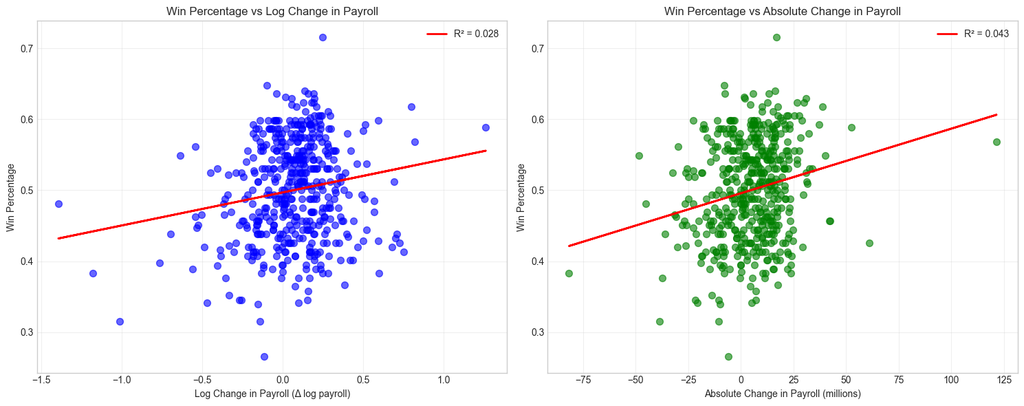

```python
# First, let's create a comprehensive dataset for analysis
analysis_data = data_sorted[['team', 'year', 'log_diff_payroll', 'win_pct']].dropna()

# Add absolute change in payroll for comparison
analysis_data = analysis_data.merge(
    data_sorted[['team', 'year', 'payroll', 'prev_payroll']].dropna(),
    on=['team', 'year'],
    how='left'
)
analysis_data['abs_payroll_change'] = analysis_data['payroll'] - analysis_data['prev_payroll']
analysis_data['percent_payroll_change'] = ((analysis_data['payroll'] - analysis_data['prev_payroll']) / analysis_data['prev_payroll']) * 100

# Calculate correlation statistics
correlation_log_diff = np.corrcoef(analysis_data['log_diff_payroll'], analysis_data['win_pct'])[0, 1]
correlation_abs_change = np.corrcoef(analysis_data['abs_payroll_change'], analysis_data['win_pct'])[0, 1]

# "STATISTICAL EVIDENCE: Log Payroll Changes vs Performance")

# Perform linear regression analysis
from scipy import stats

# Regression: Win percentage vs log payroll change
slope_log, intercept_log, r_value_log, p_value_log, std_err_log = stats.linregress(
    analysis_data['log_diff_payroll'], analysis_data['win_pct']
)

# Regression: Win percentage vs absolute payroll change
slope_abs, intercept_abs, r_value_abs, p_value_abs, std_err_abs = stats.linregress(
    analysis_data['abs_payroll_change'], analysis_data['win_pct']
)

print(f"\nREGRESSION ANALYSIS:")
print(f"Log payroll change: R² = {r_value_log**2:.4f}, p-value = {p_value_log:.4f}")
print(f"Absolute payroll change: R² = {r_value_abs**2:.4f}, p-value = {p_value_abs:.4f}")

# Create visualizations with first two plots only
fig, axes = plt.subplots(1, 2, figsize=(15, 6))

# Plot 1: Win percentage vs log change in payroll
axes[0].scatter(analysis_data['log_diff_payroll'], analysis_data['win_pct'],
                alpha=0.6, color='blue', s=50)
axes[0].plot(analysis_data['log_diff_payroll'],
             slope_log * analysis_data['log_diff_payroll'] + intercept_log,
             'r-', linewidth=2, label=f'R² = {r_value_log**2:.3f}')
axes[0].set_xlabel('Log Change in Payroll (Δ log payroll)')
axes[0].set_ylabel('Win Percentage')
axes[0].set_title('Win Percentage vs Log Change in Payroll')
axes[0].grid(True, alpha=0.3)
axes[0].legend()

# Plot 2: Win percentage vs absolute change in payroll
axes[1].scatter(analysis_data['abs_payroll_change'], analysis_data['win_pct'],
                alpha=0.6, color='green', s=50)
axes[1].plot(analysis_data['abs_payroll_change'],
             slope_abs * analysis_data['abs_payroll_change'] + intercept_abs,
             'r-', linewidth=2, label=f'R² = {r_value_abs**2:.3f}')
axes[1].set_xlabel('Absolute Change in Payroll (millions)')
axes[1].set_ylabel('Win Percentage')
axes[1].set_title('Win Percentage vs Absolute Change in Payroll')
axes[1].grid(True, alpha=0.3)
axes[1].legend()

plt.tight_layout()
plt.show()
```

If we look at plots of percent change in payroll versus win percent and change in win percent across all the data, we see only slight trends. Trends appear stronger for absolute changes in payroll than for percent changes in payrol.

This could be explained by the fact that large increases in payroll may be due to bringing on a star player if the win percent is low, which could lead to a higher win percent...In other words a bad team could improve a lot with a big payroll increase, while a good team might not improve much with a comparable payroll increase. Think of the law of diminishing returns.

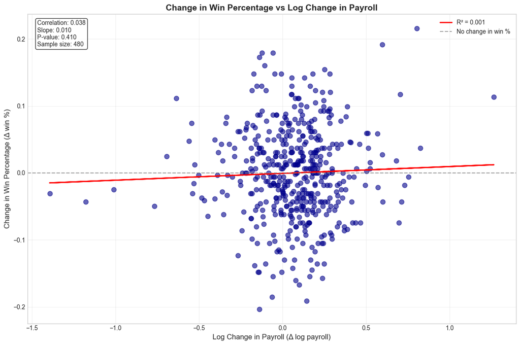

```python
# Plot win percentage change against log change in payroll
baseball_change = data_sorted.copy()
baseball_change['prev_win_pct'] = baseball_change.groupby('team')['win_pct'].shift(1)
baseball_change['diff_win'] = baseball_change['win_pct'] - baseball_change['prev_win_pct']
baseball_change['diff_log'] = baseball_change['log_diff_payroll']

# Filter for complete cases (no missing values)
change_data = baseball_change[['team', 'year', 'diff_win', 'diff_log']].dropna()

# Calculate correlation and regression

slope_change, intercept_change, r_value_change, p_value_change, std_err_change = stats.linregress(
    change_data['diff_log'], change_data['diff_win']
)

# Create the plot
plt.figure(figsize=(12, 8))
plt.scatter(change_data['diff_log'], change_data['diff_win'],
           alpha=0.6, color='darkblue', s=60)

# Add regression line
plt.plot(change_data['diff_log'],
         slope_change * change_data['diff_log'] + intercept_change,
         'r-', linewidth=2, label=f'R² = {r_value_change**2:.3f}')

# Add horizontal line at y=0 (no change in win percentage)
plt.axhline(y=0, color='gray', linestyle='--', alpha=0.7, label='No change in win %')

# Formatting
plt.xlabel('Log Change in Payroll (Δ log payroll)', fontsize=12)
plt.ylabel('Change in Win Percentage (Δ win %)', fontsize=12)
plt.title('Change in Win Percentage vs Log Change in Payroll', fontsize=14, fontweight='bold')
plt.grid(True, alpha=0.3)
plt.legend()

# Add statistics text box
stats_text = f'Correlation: {np.corrcoef(change_data["diff_log"], change_data["diff_win"])[0,1]:.3f}\n'
stats_text += f'Slope: {slope_change:.3f}\n'
stats_text += f'P-value: {p_value_change:.3f}\n'
stats_text += f'Sample size: {len(change_data)}'

plt.text(0.02, 0.98, stats_text, transform=plt.gca().transAxes,
         verticalalignment='top', bbox=dict(boxstyle='round', facecolor='white', alpha=0.8))

plt.tight_layout()
plt.show()
```

```python
# Prepare data: calculate win percent delta and percent change in payroll
data_team = data_sorted.copy()
data_team['prev_win_pct'] = data_team.groupby('team')['win_pct'].shift(1)
data_team['diff_win'] = data_team['win_pct'] - data_team['prev_win_pct']
data_team['percent_payroll_change'] = ((data_team['payroll'] - data_team['prev_payroll']) / data_team['prev_payroll']) * 100

# Filter for complete cases
data_team_reg = data_team[['team', 'year', 'diff_win', 'percent_payroll_change']].dropna()

# Fit the linear model (controlling for team)
model_pct = ols('diff_win ~ percent_payroll_change + C(team)', data=data_team_reg).fit()


print("LINEAR REGRESSION: diff_win ~ percent_payroll_change + team")

print(model_pct.summary())
```

```
LINEAR REGRESSION: diff_win ~ percent_payroll_change + team
                            OLS Regression Results
==============================================================================
Dep. Variable:               diff_win   R-squared:                       0.011
Model:                            OLS   Adj. R-squared:                 -0.055
Method:                 Least Squares   F-statistic:                    0.1728
Date:                Sun, 14 Sep 2025   Prob (F-statistic):               1.00
Time:                        21:18:51   Log-Likelihood:                 604.34
No. Observations:                 480   AIC:                            -1147.
Df Residuals:                     449   BIC:                            -1017.
Df Model:                          30
Covariance Type:            nonrobust
====================================================================================================
                                       coef    std err          t      P>|t|      [0.025      0.975]
----------------------------------------------------------------------------------------------------
Intercept                           -0.0019      0.018     -0.107      0.914      -0.037       0.033
C(team)[T.Atlanta Braves]           -0.0090      0.025     -0.360      0.719      -0.058       0.040
C(team)[T.Baltimore Orioles]         0.0079      0.025      0.315      0.753      -0.041       0.057
C(team)[T.Boston Red Sox]           -0.0071      0.025     -0.284      0.777      -0.056       0.042
C(team)[T.Chicago Cubs]             -0.0051      0.025     -0.202      0.840      -0.054       0.044
C(team)[T.Chicago White Sox]        -0.0020      0.025     -0.081      0.935      -0.051       0.047
C(team)[T.Cincinnati Reds]          -0.0010      0.025     -0.040      0.968      -0.050       0.048
C(team)[T.Cleveland Indians]        -0.0003      0.025     -0.012      0.990      -0.050       0.049
C(team)[T.Colorado Rockies]         -0.0031      0.025     -0.122      0.903      -0.052       0.046
C(team)[T.Detroit Tigers]            0.0094      0.025      0.373      0.709      -0.040       0.059
C(team)[T.Houston Astros]           -0.0110      0.025     -0.438      0.662      -0.060       0.038
C(team)[T.Kansas City Royals]        0.0067      0.025      0.269      0.788      -0.043       0.056
C(team)[T.Los Angeles Angels]        0.0058      0.025      0.233      0.816      -0.044       0.055
C(team)[T.Los Angeles Dodgers]       0.0047      0.025      0.186      0.853      -0.045       0.054
C(team)[T.Miami Marlins]             0.0079      0.025      0.316      0.752      -0.041       0.057
C(team)[T.Milwaukee Brewers]         0.0038      0.025      0.150      0.881      -0.046       0.053
C(team)[T.Minnesota Twins]           0.0005      0.025      0.020      0.984      -0.049       0.050
C(team)[T.New York Mets]            -0.0020      0.025     -0.081      0.936      -0.051       0.047
C(team)[T.New York Yankees]         -0.0107      0.025     -0.424      0.672      -0.060       0.039
C(team)[T.Oakland Athletics]         0.0060      0.025      0.237      0.812      -0.043       0.055
C(team)[T.Philadelphia Phillies]    -0.0005      0.025     -0.021      0.983      -0.050       0.049
C(team)[T.Pittsburgh Pirates]        0.0072      0.025      0.287      0.774      -0.042       0.057
C(team)[T.San Diego Padres]         -0.0069      0.025     -0.275      0.783      -0.056       0.042
C(team)[T.San Francisco Giants]      0.0007      0.025      0.029      0.977      -0.049       0.050
C(team)[T.Seattle Mariners]          0.0053      0.025      0.209      0.834      -0.044       0.055
C(team)[T.St. Louis Cardinals]       0.0038      0.025      0.151      0.880      -0.046       0.053
C(team)[T.Tampa Bay Rays]            0.0056      0.025      0.222      0.825      -0.044       0.055
C(team)[T.Texas Rangers]            -0.0072      0.025     -0.288      0.774      -0.057       0.042
C(team)[T.Toronto Blue Jays]        -0.0016      0.025     -0.062      0.950      -0.051       0.048
C(team)[T.Washington Nationals]      0.0108      0.025      0.431      0.666      -0.039       0.060
percent_payroll_change               0.0001      0.000      1.085      0.278      -0.000       0.000
==============================================================================
Omnibus:                        0.299   Durbin-Watson:                   2.669
Prob(Omnibus):                  0.861   Jarque-Bera (JB):                0.178
Skew:                           0.034   Prob(JB):                        0.915
Kurtosis:                       3.065   Cond. No.                         931.
==============================================================================

Notes:
[1] Standard Errors assume that the covariance matrix of the errors is correctly specified.
```

For every 1% increase in payroll, win percentage change increases by 0.0001 on average, controlling for team. With such a minute effect size and high p-value (0.278), percent change in payroll and team alone do not have strong predictive power for change in win percent.

#### 4.4 Comparison

First, we create models (linear regressions) for the data in aggregate due to the small number of data points (<20) per team. This was not organized by quantiles as was done in sample notebook.

(Model 1): We created a model to predict the change in win percentage, we see that payroll is a significant predictor although percent change in payroll is not. However, the effect size is larger for the percent change in payroll. The R^2 is very low, showing a weak model and poor fit.

(Model 2): If we create a linear model to predict win percent, we see that both payroll and change in payroll are significant. While payroll is more significant, change in payroll has a larger effect size suggesting greater practical importance. This model has a much larger R^2 value compared to that of model (1% vs 13%).

(Model 3): We decided to model win percent rather than change in win percent, because we wanted to measure performance on an absolute basis. If a team wins at a 20% clip and then improves to 40% the next year, they would show massive improvement in win percent. However, they still perform terribly. A team that consistently wins at a 60% is performing excellently in a baseball context.

The model has a fairly high R^2 of 0.35, so the team, payroll, and change in payroll explain about a third of the variation in win percent. This more complicated model is better than the simpler models that do not control for team effects. More variance in the data is explained, however, there remains a lot of unexplained variance, suggesting that other factors beyond payroll and team influence win percentage.

```python
# Prepare data: calculate diff_win and diff_log
bb_reg = bb.copy()
bb_reg = bb_reg.sort_values(['team', 'year'])
bb_reg['prev_win_pct'] = bb_reg.groupby('team')['win_pct'].shift(1)
bb_reg['diff_win'] = bb_reg['win_pct'] - bb_reg['prev_win_pct']
bb_reg['prev_payroll'] = bb_reg.groupby('team')['payroll'].shift(1)
bb_reg['diff_log'] = np.log(bb_reg['payroll']) - np.log(bb_reg['prev_payroll'])

# Filter for complete cases
reg_agg = bb_reg[['diff_win', 'payroll', 'diff_log']].dropna()

# Fit the model
model_agg = ols('diff_win ~ payroll + diff_log', data=reg_agg).fit()

# Show summary
print("="*80)
print("LINEAR REGRESSION: diff_win ~ payroll + diff_log (aggregate)")
print("="*80)
print(model_agg.summary())

# Key coefficients
print("\nKey coefficients:")
print(f"payroll: {model_agg.params['payroll']:.6f} (SE: {model_agg.bse['payroll']:.6f})")
print(f"diff_log: {model_agg.params['diff_log']:.6f} (SE: {model_agg.bse['diff_log']:.6f})")
print(f"p-value (payroll): {model_agg.pvalues['payroll']:.6f}")
print(f"p-value (diff_log): {model_agg.pvalues['diff_log']:.6f}")
```

```
================================================================================
LINEAR REGRESSION: diff_win ~ payroll + diff_log (aggregate)
================================================================================
                            OLS Regression Results
==============================================================================
Dep. Variable:               diff_win   R-squared:                       0.014
Model:                            OLS   Adj. R-squared:                  0.010
Method:                 Least Squares   F-statistic:                     3.453
Date:                Sun, 14 Sep 2025   Prob (F-statistic):             0.0325
Time:                        21:19:30   Log-Likelihood:                 605.03
No. Observations:                 480   AIC:                            -1204.
Df Residuals:                     477   BIC:                            -1192.
Df Model:                           2
Covariance Type:            nonrobust
==============================================================================
                 coef    std err          t      P>|t|      [0.025      0.975]
------------------------------------------------------------------------------
Intercept      0.0160      0.007      2.150      0.032       0.001       0.031
payroll       -0.0002   8.43e-05     -2.494      0.013      -0.000   -4.46e-05
diff_log       0.0141      0.012      1.134      0.257      -0.010       0.038
==============================================================================
Omnibus:                        0.196   Durbin-Watson:                   2.657
Prob(Omnibus):                  0.907   Jarque-Bera (JB):                0.095
Skew:                           0.023   Prob(JB):                        0.954
Kurtosis:                       3.052   Cond. No.                         351.
==============================================================================

Notes:
[1] Standard Errors assume that the covariance matrix of the errors is correctly specified.

Key coefficients:
payroll: -0.000210 (SE: 0.000084)
diff_log: 0.014077 (SE: 0.012409)
p-value (payroll): 0.012979
p-value (diff_log): 0.257183
```

For every 1-unit increase in payroll, win percentage change increases by -0.000210 on average, controlling for log payroll change.

For every 1-unit increase in log payroll change, win percentage change increases by 0.014077 on average, controlling for payroll.

```python
# Prepare data: calculate diff_log for each row (already done in previous steps, but ensure columns exist)
bb_reg2 = bb.copy()
bb_reg2 = bb_reg2.sort_values(['team', 'year'])
bb_reg2['prev_payroll'] = bb_reg2.groupby('team')['payroll'].shift(1)
bb_reg2['diff_log'] = np.log(bb_reg2['payroll']) - np.log(bb_reg2['prev_payroll'])

# Filter for complete cases
reg2 = bb_reg2[['win_pct', 'payroll', 'diff_log']].dropna()

# Fit the model
model2 = ols('win_pct ~ payroll + diff_log', data=reg2).fit()

# Show summary
print(model2.summary())

# Key coefficients
print("\nKey coefficients:")
print(f"payroll: {model2.params['payroll']:.6f} (SE: {model2.bse['payroll']:.6f})")
print(f"diff_log: {model2.params['diff_log']:.6f} (SE: {model2.bse['diff_log']:.6f})")
print(f"p-value (payroll): {model2.pvalues['payroll']:.6f}")
print(f"p-value (diff_log): {model2.pvalues['diff_log']:.6f}")
```

```
                            OLS Regression Results
==============================================================================
Dep. Variable:                win_pct   R-squared:                       0.137
Model:                            OLS   Adj. R-squared:                  0.133
Method:                 Least Squares   F-statistic:                     37.72
Date:                Sun, 14 Sep 2025   Prob (F-statistic):           6.18e-16
Time:                        21:19:47   Log-Likelihood:                 623.07
No. Observations:                 480   AIC:                            -1240.
Df Residuals:                     477   BIC:                            -1228.
Df Model:                           2
Covariance Type:            nonrobust
==============================================================================
                 coef    std err          t      P>|t|      [0.025      0.975]
------------------------------------------------------------------------------
Intercept      0.4471      0.007     62.552      0.000       0.433       0.461
payroll        0.0006   8.12e-05      7.748      0.000       0.000       0.001
diff_log       0.0350      0.012      2.925      0.004       0.011       0.058
==============================================================================
Omnibus:                        5.949   Durbin-Watson:                   1.266
Prob(Omnibus):                  0.051   Jarque-Bera (JB):                4.403
Skew:                          -0.107   Prob(JB):                        0.111
Kurtosis:                       2.583   Cond. No.                         351.
==============================================================================

Notes:
[1] Standard Errors assume that the covariance matrix of the errors is correctly specified.

Key coefficients:
payroll: 0.000629 (SE: 0.000081)
diff_log: 0.034960 (SE: 0.011951)
p-value (payroll): 0.000000
p-value (diff_log): 0.003606
```

For every 1-unit increase in payroll, win percentage increases by 0.000629 on average, controlling for log payroll change.

For every 1-unit increase in log payroll change, win percentage increases by 0.034960 on average, controlling for payroll.

```python
# Prepare data: ensure diff_log and team columns exist
bb_reg3 = bb.copy()
bb_reg3 = bb_reg3.sort_values(['team', 'year'])
bb_reg3['prev_payroll'] = bb_reg3.groupby('team')['payroll'].shift(1)
bb_reg3['diff_log'] = np.log(bb_reg3['payroll']) - np.log(bb_reg3['prev_payroll'])

# Filter for complete cases
reg3 = bb_reg3[['win_pct', 'payroll', 'diff_log', 'team']].dropna()

# Fit the model with team fixed effects and interaction
model3 = ols('win_pct ~ payroll + diff_log * C(team)', data=reg3).fit()

# Show summary
print(model3.summary())
```

```
                            OLS Regression Results
==============================================================================
Dep. Variable:                win_pct   R-squared:                       0.349
Model:                            OLS   Adj. R-squared:                  0.256
Method:                 Least Squares   F-statistic:                     3.750
Date:                Sun, 14 Sep 2025   Prob (F-statistic):           1.01e-15
Time:                        21:23:54   Log-Likelihood:                 691.00
No. Observations:                 480   AIC:                            -1260.
Df Residuals:                     419   BIC:                            -1005.
Df Model:                          60
Covariance Type:            nonrobust
=============================================================================================================
                                                coef    std err          t      P>|t|      [0.025      0.975]
-------------------------------------------------------------------------------------------------------------
Intercept                                     0.4678      0.018     25.877      0.000       0.432       0.503
C(team)[T.Atlanta Braves]                     0.0666      0.023      2.911      0.004       0.022       0.112
C(team)[T.Baltimore Orioles]                 -0.0327      0.022     -1.465      0.144      -0.077       0.011
C(team)[T.Boston Red Sox]                     0.0531      0.024      2.201      0.028       0.006       0.101
C(team)[T.Chicago Cubs]                      -0.0271      0.023     -1.198      0.232      -0.071       0.017
C(team)[T.Chicago White Sox]                  0.0149      0.023      0.663      0.508      -0.029       0.059
C(team)[T.Cincinnati Reds]                    0.0015      0.023      0.067      0.947      -0.043       0.046
C(team)[T.Cleveland Indians]                  0.0167      0.022      0.748      0.455      -0.027       0.060
C(team)[T.Colorado Rockies]                  -0.0278      0.023     -1.230      0.220      -0.072       0.017
C(team)[T.Detroit Tigers]                    -0.0152      0.024     -0.633      0.527      -0.062       0.032
C(team)[T.Houston Astros]                    -0.0094      0.022     -0.424      0.672      -0.053       0.034
C(team)[T.Kansas City Royals]                -0.0504      0.023     -2.242      0.026      -0.095      -0.006
C(team)[T.Los Angeles Angels]                 0.0349      0.024      1.466      0.143      -0.012       0.082
C(team)[T.Los Angeles Dodgers]                0.0311      0.023      1.343      0.180      -0.014       0.077
C(team)[T.Miami Marlins]                     -0.0038      0.023     -0.167      0.868      -0.048       0.041
C(team)[T.Milwaukee Brewers]                 -0.0170      0.023     -0.744      0.457      -0.062       0.028
C(team)[T.Minnesota Twins]                   -0.0027      0.023     -0.119      0.906      -0.048       0.042
C(team)[T.New York Mets]                     -0.0012      0.023     -0.054      0.957      -0.046       0.043
C(team)[T.New York Yankees]                   0.0589      0.028      2.121      0.034       0.004       0.113
C(team)[T.Oakland Athletics]                  0.0588      0.023      2.544      0.011       0.013       0.104
C(team)[T.Philadelphia Phillies]              0.0274      0.025      1.073      0.284      -0.023       0.077
C(team)[T.Pittsburgh Pirates]                -0.0404      0.023     -1.750      0.081      -0.086       0.005
C(team)[T.San Diego Padres]                  -0.0058      0.022     -0.260      0.795      -0.050       0.038
C(team)[T.San Francisco Giants]               0.0238      0.025      0.959      0.338      -0.025       0.073
C(team)[T.Seattle Mariners]                  -0.0168      0.023     -0.733      0.464      -0.062       0.028
C(team)[T.St. Louis Cardinals]                0.0609      0.024      2.573      0.010       0.014       0.107
```

[output cut: 31 more lines]

```
diff_log:C(team)[T.Tampa Bay Rays]           -0.0425      0.073     -0.585      0.559      -0.185       0.100
diff_log:C(team)[T.Texas Rangers]            -0.1081      0.086     -1.261      0.208      -0.276       0.060
diff_log:C(team)[T.Toronto Blue Jays]        -0.1248      0.085     -1.466      0.143      -0.292       0.043
diff_log:C(team)[T.Washington Nationals]     -0.1163      0.080     -1.462      0.144      -0.273       0.040
==============================================================================
Omnibus:                        1.151   Durbin-Watson:                   1.576
Prob(Omnibus):                  0.562   Jarque-Bera (JB):                1.219
Skew:                          -0.114   Prob(JB):                        0.544
Kurtosis:                       2.907   Cond. No.                     1.08e+04
==============================================================================

Notes:
[1] Standard Errors assume that the covariance matrix of the errors is correctly specified.
[2] The condition number is large, 1.08e+04. This might indicate that there are
strong multicollinearity or other numerical problems.
```